# Urban Growth Modeling for Pittsburgh Metropolitan Statistical Area

Planning Memo to Southwestern Pennsylvania Commission

[Xinyi Qiu](https://xy16-5.github.io/) and [Gillian Xuezhu Zhao](https://gillianzhaoxz.github.io/web/)

5/10/2021

# 1 Introduction

Since its days as the Forge of America, Pittsburgh, the biggest city in Pittsburgh MSA, has changed dramatically in its over 250-year history. With decreasing population, decayed structures, and yet suburban sprawl, the region is eager to redevelop many of its areas and neighborhoods[^1].

We completed the growth modeling project in anticipation of the Southwestern Pennsylvania Commission (SPC)’s next large-scale comprehensive planning process for Pittsburgh Metropolitan Statistical Area (MSA).

[figure not shown]

Pittsburgh MSA Conuties

Our findings aim to help planners model the interplay between supply and demand-side insights and guide new development across to places where growth can have economic and sustainable impacts.

# 2 Exploratory Analysis

## 2.1 Feature Engineering

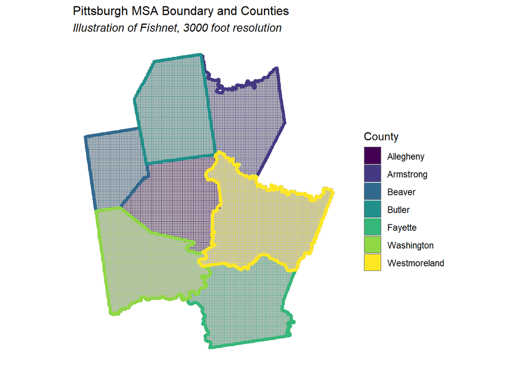

We forecasted change in development for 2021 with patterns from 2001-2011 through a binary logistic regression model per each 3000 foot fishnet grid.

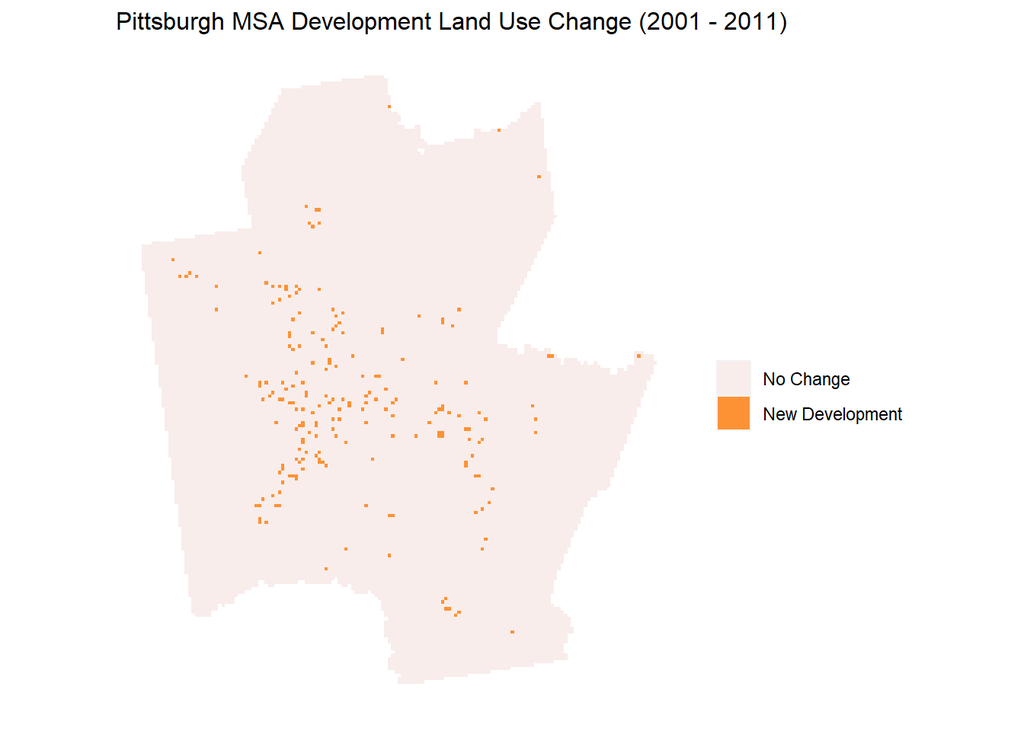

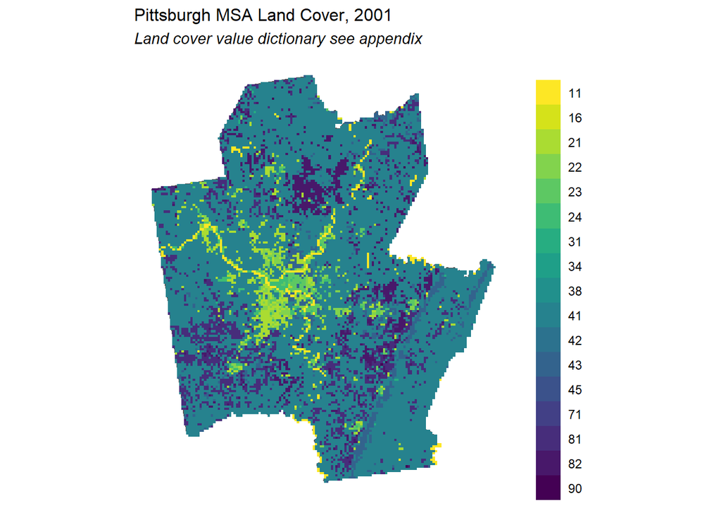

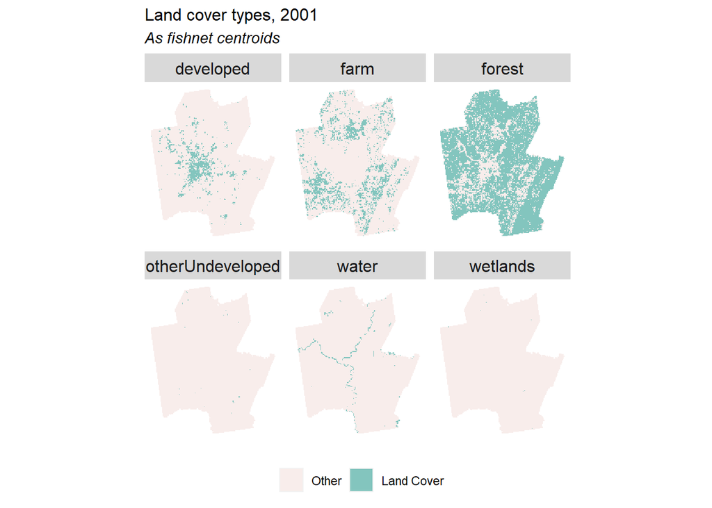

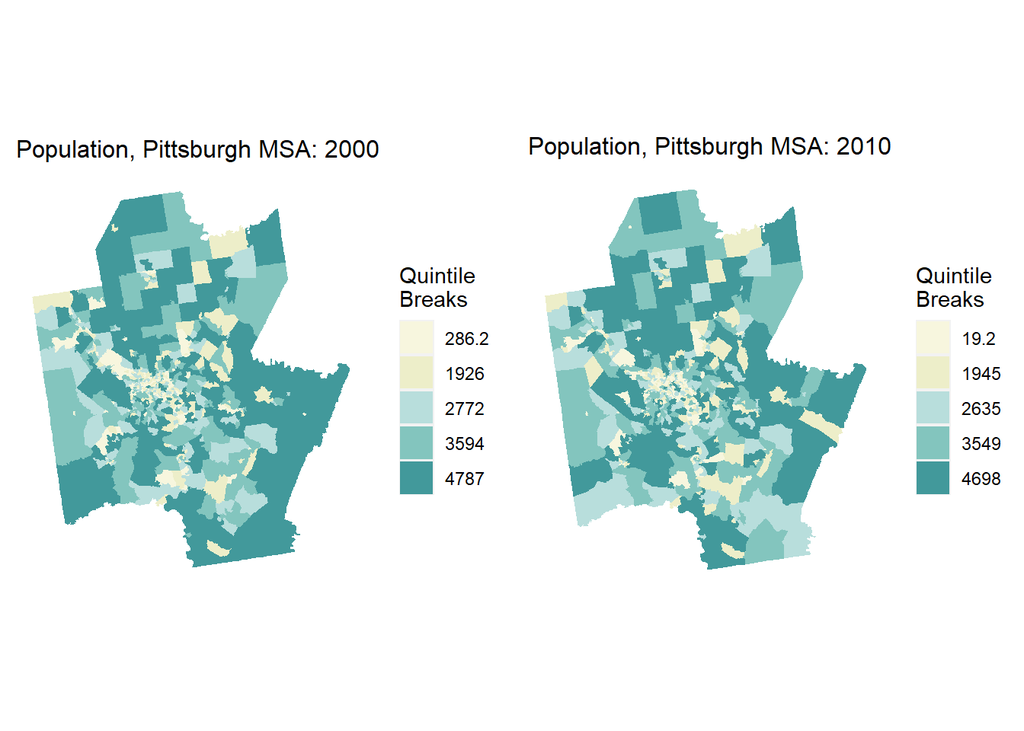

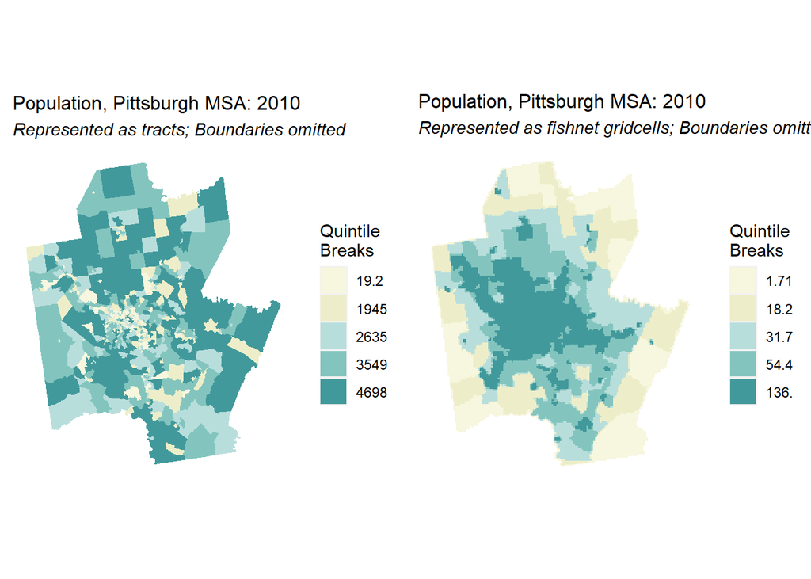

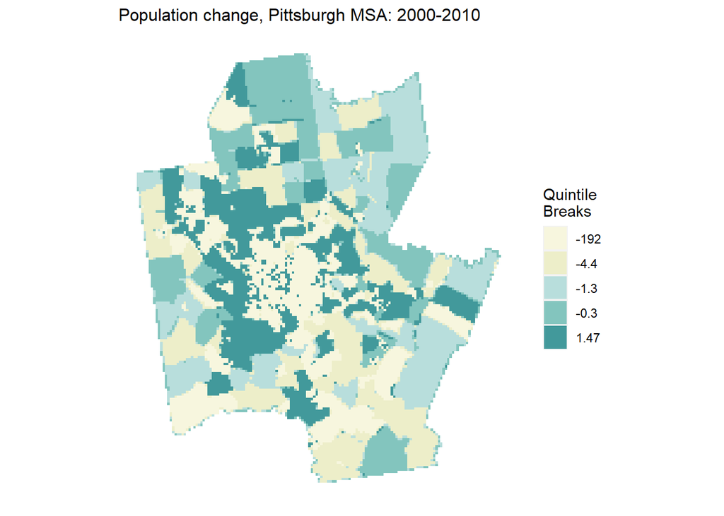

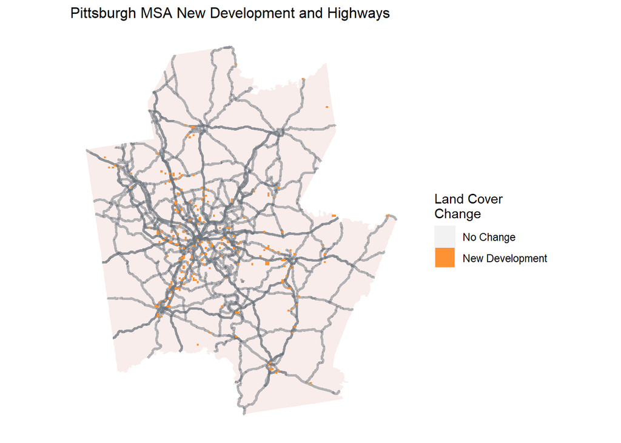

[figure not shown]

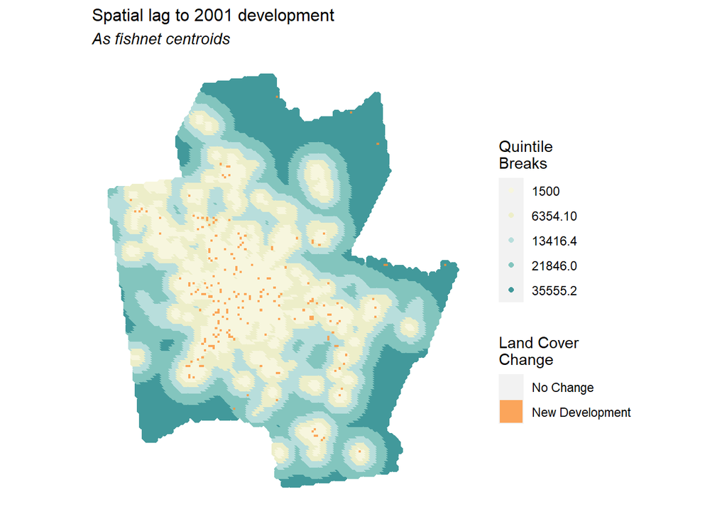

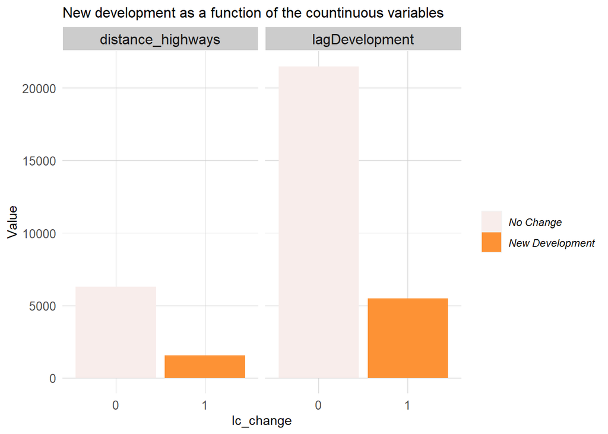

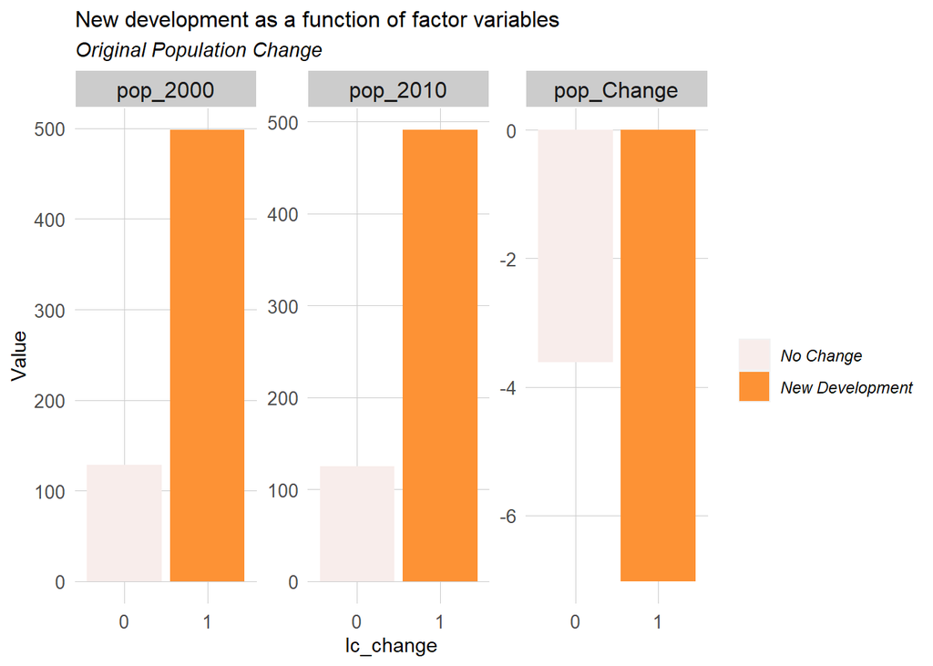

| Land_Cover_Type | Conversion_Rate |
| --- | --- |
| Developed | 0.19% |
| Farm | 0.24% |
| Forest | 0.67% |
| Other Undeveloped | 0.01% |
| wetlands_2001 | 0% |

# 3 Modeling

## 3.1 Model Selection

|  | *Dependent variable:* |  |  |  |  |  |
| --- | --- | --- | --- | --- | --- | --- |
|  | lc_change |  |  |  |  |  |
|  | (1) | (2) | (3) | (4) | (5) | (6) |
| wetlands_2001 | -11.481 | -9.750 | -8.750 | -8.589 | -9.792 | -9.498 |
|  | (550.089) | (796.695) | (801.904) | (801.668) | (796.463) | (765.719) |
| forest_2001 | -0.524 | 1.986*** | 2.798*** | 2.927*** | 1.940*** | 1.976*** |
|  | (0.327) | (0.358) | (0.435) | (0.460) | (0.359) | (0.359) |
| farm_2001 | -0.194 | 2.630*** | 3.574*** | 3.718*** | 2.585*** | 2.684*** |
|  | (0.378) | (0.426) | (0.510) | (0.534) | (0.427) | (0.429) |
| otherUndeveloped_2001 | -11.481 | -9.752 | -9.173 | -8.983 | -9.718 | -9.713 |
|  | (438.819) | (607.616) | (619.700) | (619.406) | (607.648) | (592.778) |
| lagDevelopment |  | -0.0003*** | -0.0003*** | -0.0003*** | -0.0003*** | -0.0003*** |
|  |  | (0.00004) | (0.00004) | (0.00004) | (0.00004) | (0.00004) |
| pop_2000 |  |  | 0.001*** | -0.001 |  |  |
|  |  |  | (0.0002) | (0.001) |  |  |
| pop_2010 |  |  |  | 0.003*** |  |  |
|  |  |  |  | (0.001) |  |  |
| pop_Change |  |  |  |  | 0.002 | 0.002* |
|  |  |  |  |  | (0.001) | (0.001) |
| distance_highways |  |  |  |  |  | -0.0002*** |
|  |  |  |  |  |  | (0.00004) |
| Constant | -4.085*** | -3.502*** | -4.888*** | -5.072*** | -3.442*** | -3.325*** |
|  | (0.304) | (0.310) | (0.487) | (0.520) | (0.311) | (0.312) |
| Observations | 9,143 | 9,143 | 9,143 | 9,143 | 9,143 | 9,143 |
| Log Likelihood | -549.121 | -433.668 | -422.611 | -418.417 | -432.536 | -425.628 |
| Akaike Inf. Crit. | 1,108.242 | 879.337 | 859.222 | 852.833 | 879.072 | 867.257 |
| *Note:* | p<0.1; p<0.05; p<0.01 |  |  |  |  |  |

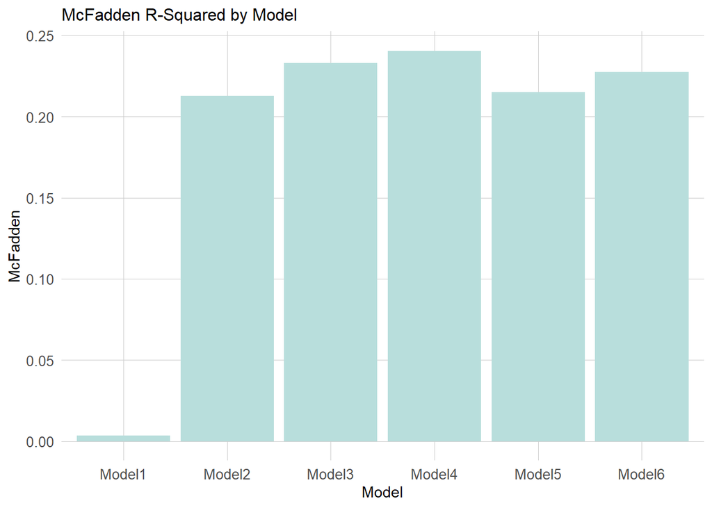

## 3.2 Model Outcome

### 3.2.1 Original plot

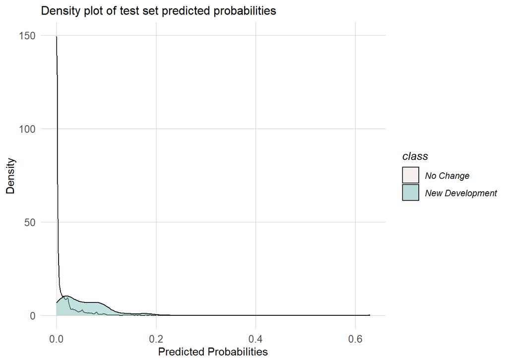

### 3.2.2 Zoomed-in plot

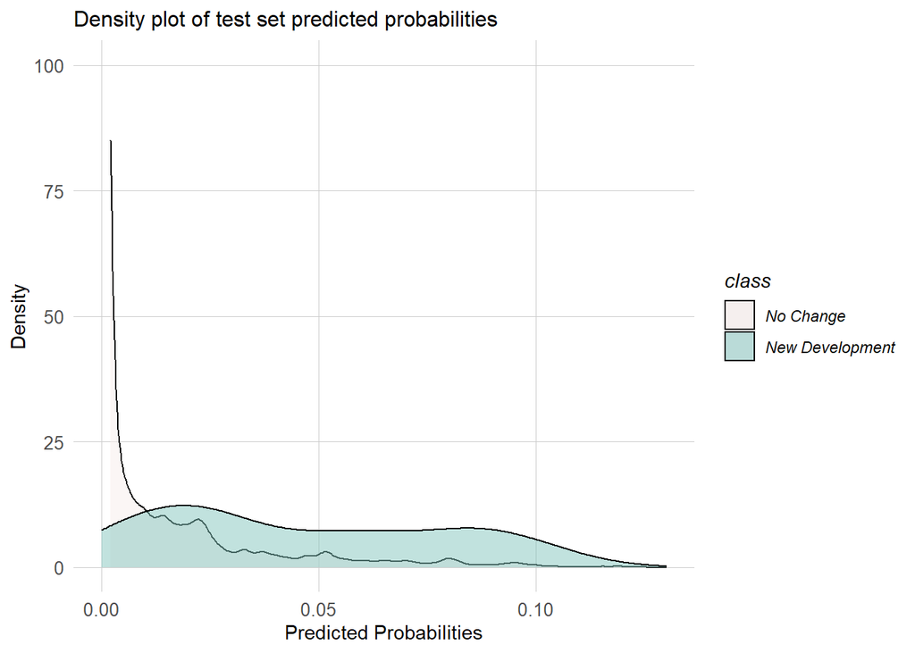

| Variable | Sensitivity | Specificity | Accuracy |
| --- | --- | --- | --- |
| predClass_01 | 0.86 | 0.73 | 0.73 |
| predClass_02 | 0.77 | 0.82 | 0.82 |
| predClass_03 | 0.59 | 0.89 | 0.88 |
| predClass_05 | 0.48 | 0.94 | 0.93 |

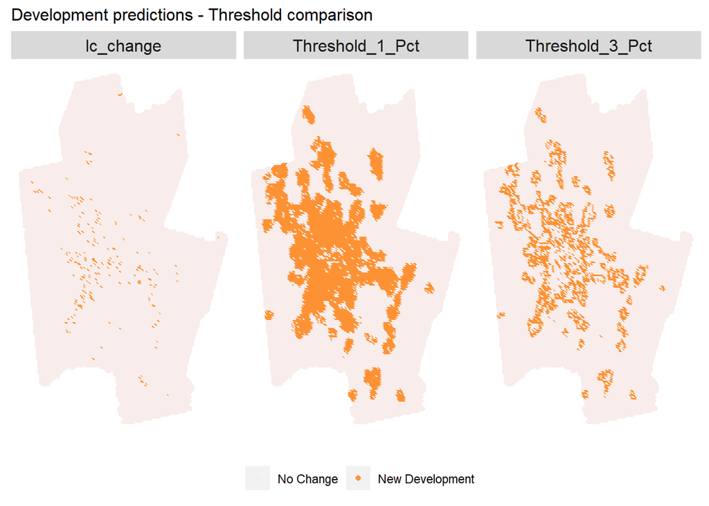

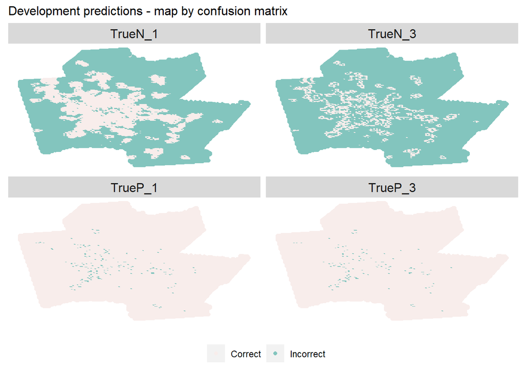

## 3.3 Model Validation

| county | Observed_Change | Sensitivity | Specificity | Accuracy |
| --- | --- | --- | --- | --- |
| Allegheny | 88 | 0.67 | 0.67 | 0.67 |
| Armstrong | 3 | 0.33 | 0.97 | 0.97 |
| Beaver | 9 | 0.44 | 0.86 | 0.86 |
| Butler | 19 | 0.58 | 0.91 | 0.91 |
| Fayette | 11 | 0.73 | 0.95 | 0.95 |
| Washington | 34 | 0.76 | 0.91 | 0.91 |
| Westmoreland | 39 | 0.56 | 0.91 | 0.91 |

# 4 2021 Forecast

## 4.1 Demande-side Change

### 4.1.1 Population change

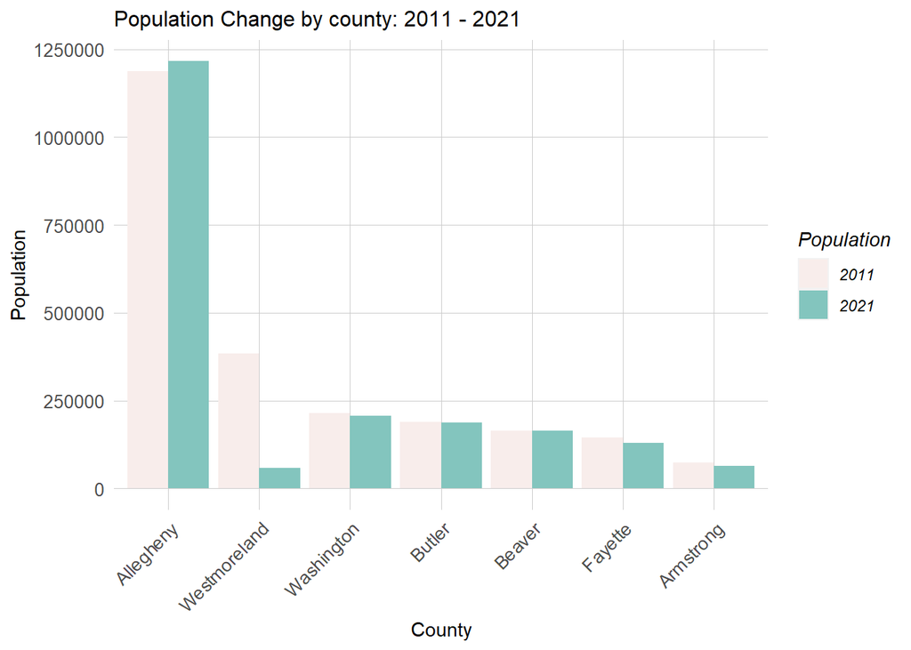

### 4.1.2 Land cover change

To picture 2021 land use scenario, we will project the change base on 2001-2011 pattern.

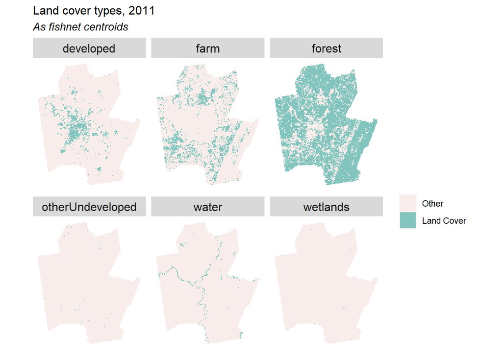

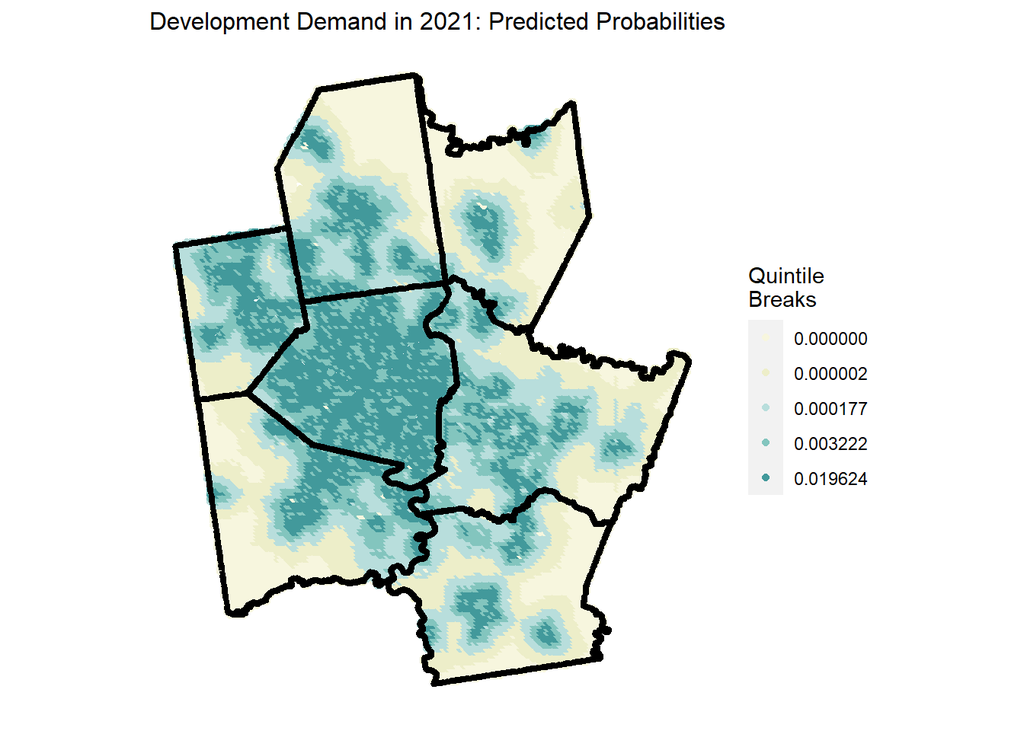

## 4.2 Impact

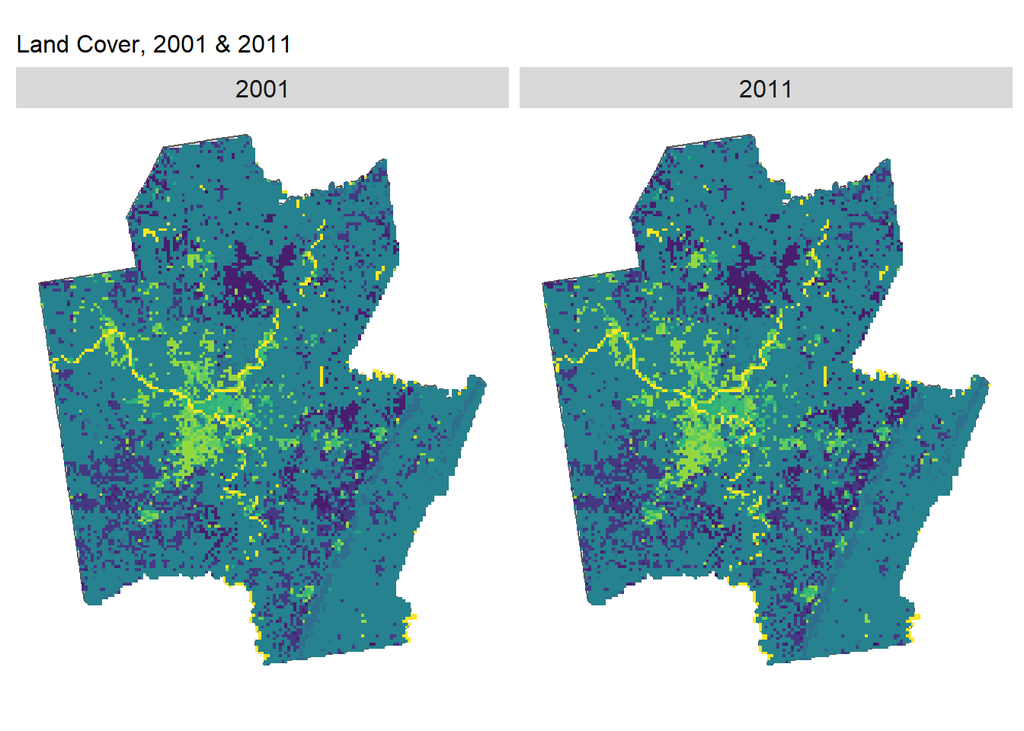

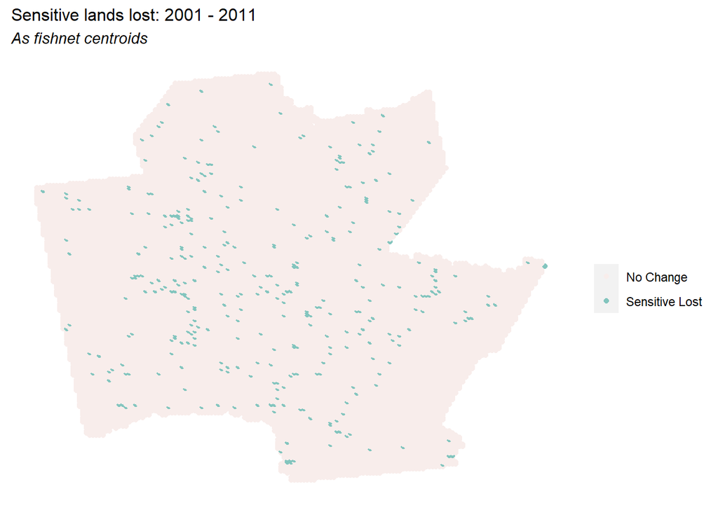

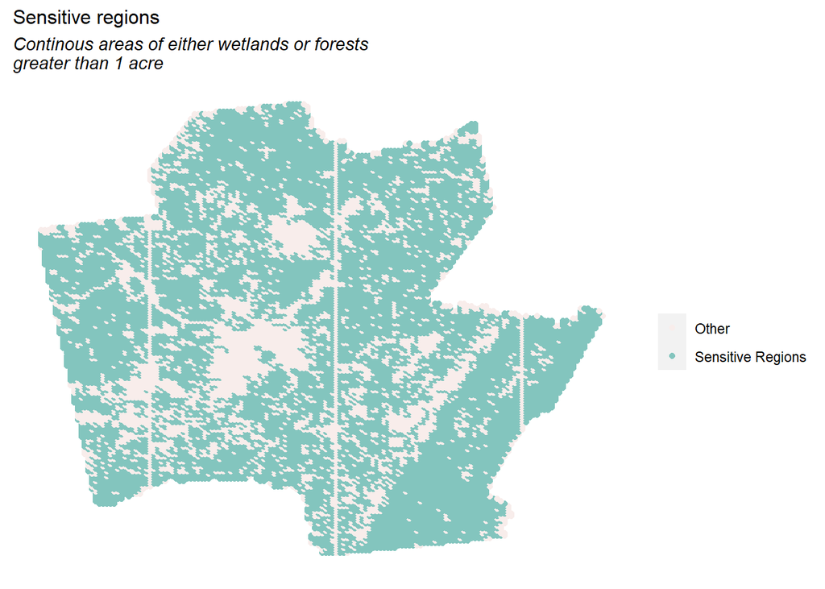

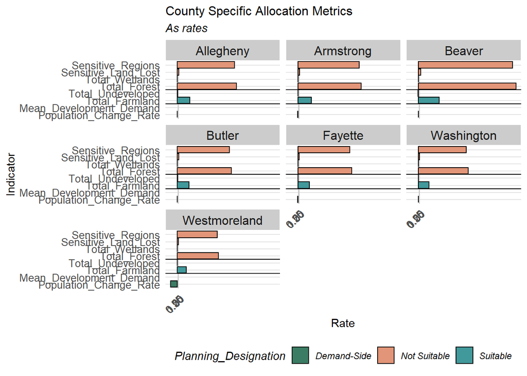

# 5 Allocation

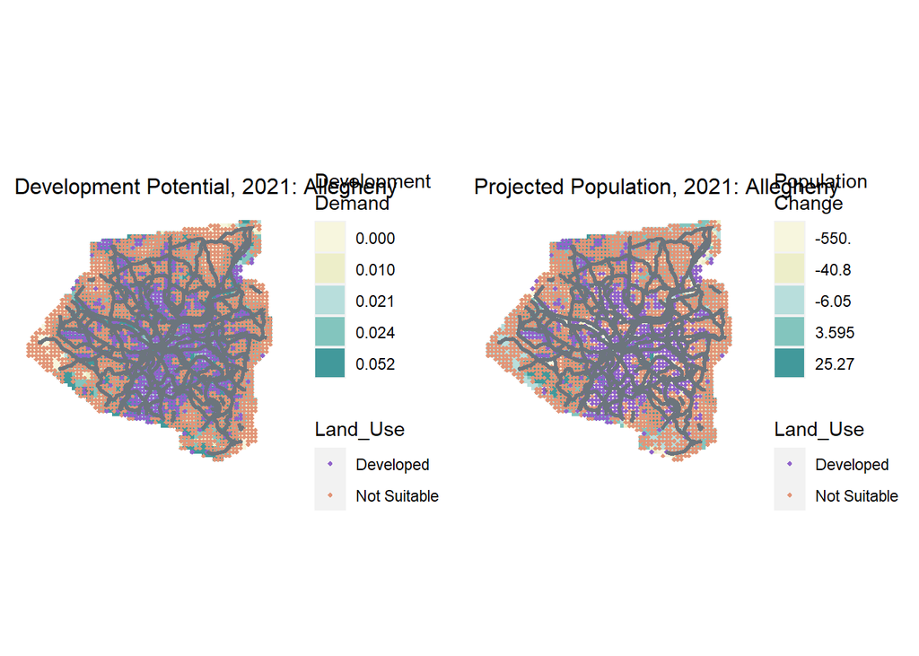

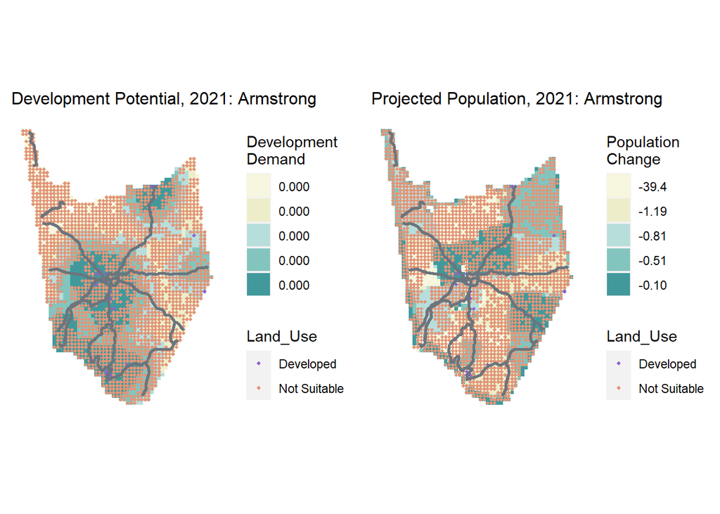

# 6 Appendices

## 6.1 Data Dictionary

### 6.1.1 Land cover change data

The table below shows descriptions of each categorical land cover type in the land cover data, which corresponds to the numeric values.

| Definition | Value |
| --- | --- |
| Open Water - All areas of open water, generally with less than 25% cover or vegetation or soil. | 11 |
| Perennial Ice/Snow - All areas characterized by a perennial cover of ice and/or snow, generally greater than 25% of total cover. | 12 |
| Developed, Open Space - Includes areas with a mixture of some constructed materials, but mostly vegetation in the form of lawn grasses. Impervious surfaces account for less than 20 percent of total co… | 21 |
| Developed, Low Intensity -Includes areas with a mixture of constructed materials and vegetation. Impervious surfaces account for 20-49 percent of total cover. These areas most commonly include single-… | 22 |
| Developed, Medium Intensity - Includes areas with a mixture of constructed materials and vegetation. Impervious surfaces account for 50-79 percent of the total cover. These areas most commonly include… | 23 |
| Developed, High Intensity - Includes highly developed areas where people reside or work in high numbers. Examples include apartment complexes, row houses and commercial/industrial. Impervious surfaces… | 24 |
| Barren Land (Rock/Sand/Clay) - Barren areas of bedrock, desert pavement, scarps, talus, slides, volcanic material, glacial debris, sand dunes, strip mines, gravel pits and other accumulations of earth… | 31 |
| Deciduous Forest - Areas dominated by trees generally greater than 5 meters tall, and greater than 20% of total vegetation cover. More than 75 percent of the tree species shed foliage simultaneously i… | 41 |
| Evergreen Forest - Areas dominated by trees generally greater than 5 meters tall, and greater than 20% of total vegetation cover. More than 75 percent of the tree species maintain their leaves all yea… | 42 |
| Mixed Forest - Areas dominated by trees generally greater than 5 meters tall, and greater than 20% of total vegetation cover. Neither deciduous nor evergreen species are greater than 75 percent of tot… | 43 |
| Dwarf Scrub - Alaska only areas dominated by shrubs less than 20 centimeters tall with shrub canopy typically greater than 20% of total vegetation. This type is often co-associated with grasses, sedge… | 51 |
| Shrub/Scrub - Areas dominated by shrubs; less than 5 meters tall with shrub canopy typically greater than 20% of total vegetation. This class includes true shrubs, young trees in an early successional… | 52 |
| Grassland/Herbaceous - Areas dominated by grammanoid or herbaceous vegetation, generally greater than 80% of total vegetation. These areas are not subject to intensive management such as tilling, but … | 71 |
| Sedge/Herbaceous - Alaska only areas dominated by sedges and forbs, generally greater than 80% of total vegetation. This type can occur with significant other grasses or other grass like plants, and i… | 72 |
| Lichens - Alaska only areas dominated by fruticose or foliose lichens generally greater than 80% of total vegetation. | 73 |
| Moss - Alaska only areas dominated by mosses, generally greater than 80% of total vegetation. | 74 |
| Pasture/Hay - Areas of grasses, legumes, or grass-legume mixtures planted for livestock grazing or the production of seed or hay crops, typically on a perennial cycle. Pasture/hay vegetation accounts … | 81 |
| Cultivated Crops - Areas used for the production of annual crops, such as corn, soybeans, vegetables, tobacco, and cotton, and also perennial woody crops such as orchards and vineyards. Crop vegetatio… | 82 |
| Woody Wetlands - Areas where forest or shrub land vegetation accounts for greater than 20 percent of vegetative cover and the soil or substrate is periodically saturated with or covered with water. | 90 |
| Emergent Herbaceous Wetlands - Areas where perennial herbaceous vegetation accounts for greater than 80 percent of vegetative cover and the soil or substrate is periodically saturated with or covered … | 95 |

Source  
https://www.mrlc.gov/data/nlcd-2001-2011-land-cover-change-conus

### 6.1.2 Land Cover Classification

The table below shows how we reclassify land cover data into more useful categories.

[output not shown]

## 6.2 Code

### 6.2.1 Preparation

```r
library(tidyverse)
library(sf)
library(raster)
library(knitr)
library(formattable)
library(tidycensus)
library(tigris)
options(tigris_class = "sf")
options(tigris_use_cache = TRUE)
library(FNN)
library(QuantPsyc)
library(caret)
library(yardstick)
library(pscl)
library(plotROC)
library(ggrepel)
library(pROC)
library(grid)
library(gridExtra)
library(viridis)
library(exactextractr)
library(stringr)
library(censusapi)
library(ROCR)

mapTheme <- function(base_size = 12) {
  theme(
    text = element_text( color = "black"),
    plot.title = element_text(size = 14,colour = "black"),
    plot.subtitle=element_text(face="italic"),
    plot.caption=element_text(hjust=0),
    axis.ticks = element_blank(),
    panel.background = element_blank(),axis.title = element_blank(),
    axis.text = element_blank(),
    axis.title.x = element_blank(),
    axis.title.y = element_blank(),
    panel.grid.minor = element_blank(),
    panel.border = element_rect(colour = "black", fill=NA, size=2)
  )
}

plotTheme <- function(base_size = 12) {
  theme(
    text = element_text( color = "black"),
    plot.title = element_text(size = 14,colour = "black"),
    plot.subtitle = element_text(face="italic"),
    plot.caption = element_text(hjust=0),
    axis.ticks = element_blank(),
    panel.background = element_blank(),
    panel.grid.major = element_line("grey80", size = 0.1),
    panel.grid.minor = element_blank(),
    panel.border = element_rect(colour = "black", fill=NA, size=2),
    strip.background = element_rect(fill = "grey80", color = "white"),
    strip.text = element_text(size=12),
    axis.title = element_text(size=12),
    axis.text = element_text(size=10),
    plot.background = element_blank(),
    legend.background = element_blank(),
    legend.title = element_text(colour = "black", face = "italic"),
    legend.text = element_text(colour = "black", face = "italic"),
    strip.text.x = element_text(size = 14)
  )
}

palette2 <- c("#41b6c4","#253494")
palette4 <- c("#a1dab4","#41b6c4","#2c7fb8","#253494")
palette5 <- c("#ffffcc","#a1dab4","#41b6c4","#2c7fb8","#253494")
palette10 <- c("#f7fcf0","#e0f3db","#ccebc5","#a8ddb5","#7bccc4",
               "#4eb3d3","#2b8cbe","#0868ac","#084081","#f7fcf0")
```

```r
quintileBreaks <- function(df,variable) {
    as.character(quantile(df[[variable]],
                          c(.01,.2,.4,.6,.8),na.rm=T))
}

#This function can be used to convert a polygon sf to centroids xy coords.
xyC <- function(aPolygonSF) {
  as.data.frame(
    cbind(x=st_coordinates(st_centroid(aPolygonSF))[,1],
          y=st_coordinates(st_centroid(aPolygonSF))[,2]))
}

#this function convert a raster to a data frame so it can be plotted in ggplot
rast <- function(inRaster) {
  data.frame(
    xyFromCell(inRaster, 1:ncell(inRaster)),
    value = getValues(inRaster)) }

nn_function <- function(measureFrom,measureTo,k) {
  #convert the sf layers to matrices
  measureFrom_Matrix <-
    as.matrix(measureFrom)
  measureTo_Matrix <-
    as.matrix(measureTo)
  nn <-
    get.knnx(measureTo, measureFrom, k)$nn.dist
    output <-
    as.data.frame(nn) %>%
    rownames_to_column(var = "thisPoint") %>%
    gather(points, point_distance, V1:ncol(.)) %>%
    arrange(as.numeric(thisPoint)) %>%
    group_by(thisPoint) %>%
    summarize(pointDistance = mean(point_distance)) %>%
    arrange(as.numeric(thisPoint)) %>%
    dplyr::select(-thisPoint) %>%
    pull()

  return(output)
}
```

### 6.2.2 Land Use Change Data and Create Fishnet

```r
# Xinyi's
# Pittsburgh_MSA <-
#   st_read("Pittsburgh_MSA/Pittsburgh_MSA.shp") %>%
#   st_transform(102741) #102003
#
# Pittsburgh_MSA_boundary <- Pittsburgh_MSA %>%
#   group_by(STATEFP) %>%
#   summarise() %>%
#   st_transform(102741)

# Gillian's
Pittsburgh_MSA <-
  st_read("Pittsburgh_MSA/Pittsburgh_MSA.shp") %>%
  st_transform("ESRI:102741") #102003

Pittsburgh_MSA_boundary <- Pittsburgh_MSA %>%
  group_by(STATEFP) %>%
  summarise() %>%
  st_transform("ESRI:102741")

MSA_fishnet <-
  st_make_grid(Pittsburgh_MSA_boundary, 3000) %>%
  st_sf()

MSA_fishnet <-
  MSA_fishnet[Pittsburgh_MSA_boundary,]

ggplot()+
  labs(title="Pittsburgh MSA Boundary and Counties",
       subtitle="Illustration of Fishnet, 3000 foot resolution")+
  geom_sf(data=Pittsburgh_MSA, aes(fill=as.factor(NAME)))+
  geom_sf(data=MSA_fishnet, fill=NA, color="gray", alpha=0.5) +
  geom_sf(data=Pittsburgh_MSA, fill=NA, size=1.5, aes(colour=as.factor(NAME)))+
  scale_color_viridis(discrete = T,
                     name ="County")+
  scale_fill_viridis(discrete = T,
                     name ="County")+
  mapTheme()

lc_2001 <- raster("msa_2001lc.tif")
lc_2001 <-projectRaster(lc_2001,crs=crs(Pittsburgh_MSA))

lc_2011 <- raster ("msa_2011lc.tif")
lc_2011 <- projectRaster(lc_2011,crs=crs(Pittsburgh_MSA) )

# aggregate
lc_2001 <- raster::aggregate(lc_2001, fact = 30, fun = modal)
lc_2011 <- raster::aggregate(lc_2011, fact = 30, fun = modal)

# calculate
lc_change <- (lc_2001 != lc_2011) * lc_2011

reclassMatrix <-
  matrix(c(
    0,12,0,
    12,24,1,
    24,Inf,0),
    ncol=3, byrow=T)
lc_change_reclass <- reclassify(lc_change, reclassMatrix)
lc_change_reclass[lc_change_reclass < 1] <- 0
names(lc_change_reclass) <- "lc_change_reclass"

lc_change_extract <- data.frame(exact_extract(lc_change_reclass, MSA_fishnet, fun = "mode"))
names(lc_change_extract) <- "developed_2011"

MSA_fishnet <- cbind(data.frame(MSA_fishnet),lc_change_extract)

# Xinyi's
# MSA_fishnet <-
#   MSA_fishnet %>%
#   st_as_sf(.) %>%
#   st_transform(102741)

MSA_fishnet <-
  MSA_fishnet %>%
  st_as_sf(.) %>%
  st_transform("ESRI:102741")

# Plot
ggplot() +
   geom_sf(data=MSA_fishnet,aes(fill=as.factor(developed_2011)),color='transparent')+
   scale_fill_viridis(discrete=TRUE, name ="Land Cover\nChange",labels=c("No Change","New Development")) +
  labs(title="Pittsburgh MSA Development Land Use Change (2001 - 2011)") +
  mapTheme()

ggplot() +
  geom_sf(data=Pittsburgh_MSA_boundary) +
  geom_raster(data=rast(lc_2001) %>% na.omit %>% filter(value > 0),
              aes(x,y,fill=as.factor(round(value,0)))) +
  scale_fill_viridis(discrete=TRUE,direction=-1, name ="") +
  labs(title = "Pittsburgh MSA Land Cover, 2001") +
  mapTheme()

developed <- lc_2001 == 21 | lc_2001 == 22 | lc_2001 == 23 | lc_2001 == 24
forest <- lc_2001 == 41 | lc_2001 == 42 | lc_2001 == 43
farm <- lc_2001 == 81 | lc_2001 == 82
wetlands <- lc_2001 == 90 | lc_2001 == 95
otherUndeveloped <- lc_2001 == 52 | lc_2001 == 71 | lc_2001 == 31
water <- lc_2001 == 11
names(developed) <- "developed"
names(forest) <- "forest"
names(farm) <- "farm"
names(wetlands) <- "wetlands"
names(otherUndeveloped) <- "otherUndeveloped"
names(water) <- "water"

layer_list <- list(developed, wetlands, forest, farm, otherUndeveloped, water)
names(layer_list) <- c("developed_2001", "wetlands_2001", "forest_2001",
                       "farm_2001", "otherUndeveloped_2001", "water_2001")

fish_extract <- function(fishnet, layers) {

  extract_list <- exact_extract(layers, fishnet, fun = "mode")

  return(extract_list)

}


lc_2001_extracts <- lapply(layer_list, fish_extract, fishnet = MSA_fishnet)
lc_2001_extracts <- data.frame(do.call(cbind, args = lc_2001_extracts))
MSA_fishnet <- cbind(data.frame(MSA_fishnet), lc_2001_extracts)

# Xinyi's
# MSA_fishnet <-
#   MSA_fishnet %>%
#   st_as_sf(.) %>%
#   st_transform(102741)

MSA_fishnet <-
  MSA_fishnet %>%
  st_as_sf(.) %>%
  st_transform("ESRI:102741")

lc_2001_lcvar <-
  MSA_fishnet %>%
  gather(var,value,developed_2001:water_2001) %>%
  dplyr::select(var,value,geometry)

lc_2001_lcvar$var <- as.factor(str_sub(lc_2001_lcvar$var,1,-6))

# Plot
ggplot()+
  geom_sf(data=lc_2001_lcvar,aes(fill=as.factor(value)),color='transparent')+
  facet_wrap(~var)+
  scale_fill_viridis(discrete=TRUE, labels=c("Other","Land Cover"),name ="")+
    labs(title = "Land cover types, 2001",
         subtitle = "As fishnet centroids") +
   mapTheme()
```

### 6.2.3 Predicting Features Data

```r
# Population
MSAPop10 <-
  get_decennial(geography = "tract",variables = "P001001",year=2010,
                state=42,county=c("Allegheny County","Armstrong County","Beaver County","Butler County","Fayette County",
                                  "Washington County","Westmoreland County"),geometry=TRUE) %>%
  rename(pop_2010 = value) %>%
  st_transform(st_crs(MSA_fishnet))

Sys.setenv(CENSUS_KEY = "2c3e9f9d2d65abab5f7b81fe418054415d363a43")
MSAPop00 <-getCensus(name = "dec/sf1",
                  vintage = 2000,
                  vars = c("NAME","P001001"),
                  region = "tract:*",
                  regionin = "state:42+county:003,005,007,019,051,125,129")
MSAPop00$label <- paste0(MSAPop00$county,"0",MSAPop00$tract)
for (i in 1:721){
  if(nchar(MSAPop00[i,]$label)!=10){
    MSAPop00[i,]$label <-paste0(MSAPop00[i,]$label,"00")
  }

}

# Xinyi's
# MSAtracts00 <- st_read("MSAtracts/MSAtracts.shp") %>%
#  st_transform(102741)

# Gillian's
MSAtracts00 <- st_read("MSAtracts/MSAtracts.shp") %>%
  st_transform("ESRI:102741")

MSAtracts00$tract <-substr(MSAtracts00$GISJOIN2 ,4,13)
MSAtracts00$tract <- as.character(MSAtracts00$tract)

MSAPop00 <- left_join(MSAtracts00, MSAPop00,by=c("tract"="label"))
MSAPop00 <- MSAPop00 %>%
  dplyr::select(GISJOIN2,NAME,P001001,geometry) %>%
  rename(GEOID = GISJOIN2,pop_2000 = P001001)

# Plot
grid.arrange(
ggplot() +
  geom_sf(data = MSAPop00, aes(fill=factor(ntile(pop_2000,5))), colour=NA) +
  scale_fill_manual(values = palette5,
                    labels=quintileBreaks(MSAPop00,"pop_2000"),
                   name="Quintile\nBreaks") +
  labs(title="Population, Pittsburgh MSA: 2000") +
  mapTheme(),

ggplot() +
  geom_sf(data = MSAPop10, aes(fill=factor(ntile(pop_2010,5))), colour=NA) +
  scale_fill_manual(values = palette5,
                    labels=quintileBreaks(MSAPop10,"pop_2010"),
                   name="Quintile\nBreaks") +
  labs(title="Population, Pittsburgh MSA: 2010") +
  mapTheme(), ncol=2)

# To fishnet
MSA_fishnet <-
  MSA_fishnet %>%
  rownames_to_column("fishnetID") %>%
  mutate(fishnetID = as.numeric(fishnetID))

fishnetPop00 <-
  st_interpolate_aw(MSAPop00["pop_2000"],MSA_fishnet,extensive=TRUE) %>%
  as.data.frame(.) %>%
  left_join(MSA_fishnet,.,by="geometry") %>%
  mutate(pop_2000=replace_na(pop_2000,0)) %>%
  dplyr::select(fishnetID,pop_2000)

fishnetPop10 <-
  st_interpolate_aw(MSAPop10["pop_2010"],MSA_fishnet,extensive=TRUE) %>%
  as.data.frame(.) %>%
  left_join(MSA_fishnet,.,by="geometry") %>%
  mutate(pop_2010=replace_na(pop_2010,0)) %>%
  dplyr::select(pop_2010,fishnetID)

fishnetPop <-
  cbind(fishnetPop00,fishnetPop10) %>%
  dplyr::select(pop_2000,pop_2010,fishnetID) %>%
  mutate(pop_Change = pop_2010 - pop_2000) %>%
  st_drop_geometry(.)


MSA_fishnet <- left_join(MSA_fishnet,data.frame(fishnetPop),by="fishnetID")

# Highway
PittsburghHighways <-
  st_read("MSAHighways/MSAHighways.shp") %>%
  st_transform(st_crs(Pittsburgh_MSA)) %>%
  st_intersection(Pittsburgh_MSA_boundary)

PittsburghHighways <-
  PittsburghHighways %>%
  dplyr::select(CTY_CODE, DISTRICT_N,MAINT_FUNC,geometry)

# Plot
ggplot() +
  geom_sf(data=MSA_fishnet,aes(fill=as.factor(developed_2011)),color='transparent') +
  geom_sf(data=PittsburghHighways,color='white') +
  scale_fill_viridis(discrete=TRUE, name ="Land Cover\nChange",labels=c("No Change","New Development")) +
  labs(title = "Pittsburgh MSA New Development and Highways") +
  mapTheme()

# Distance to highway

emptyRaster <- lc_change
emptyRaster[] <- NA

highway_raster <-
  as(PittsburghHighways,'Spatial') %>%
  rasterize(.,emptyRaster)

# writeRaster(highway_raster,"highway_raster.tif")

highway_raster_distance <- distance(highway_raster)
names(highway_raster_distance) <- "distance_highways"

highwayPoints <-
  rasterToPoints(highway_raster_distance) %>%
  as.data.frame() %>%
  st_as_sf(coords = c("x", "y"), crs = st_crs(MSA_fishnet))

highwayPoints_fishnet <-
  aggregate(highwayPoints, MSA_fishnet, mean) %>%
  mutate(distance_highways = ifelse(is.na(distance_highways),0,distance_highways)) %>%
  rownames_to_column("fishnetID") %>%
  mutate(fishnetID = as.numeric(fishnetID))


highwayPoints_fishnet <-highwayPoints_fishnet %>%
  st_drop_geometry(.)

MSA_fishnet <- left_join(MSA_fishnet,highwayPoints_fishnet,by="fishnetID")

# Plot dist to highway
ggplot() +
  geom_sf(data=Pittsburgh_MSA_boundary) +
  geom_point(data=MSA_fishnet , aes(x=xyC(MSA_fishnet )[,1],
                                             y=xyC(MSA_fishnet)[,2],
                 colour=factor(ntile(distance_highways,5))),size=1.5) +
  scale_colour_manual(values = palette5,
                      labels=substr(quintileBreaks(MSA_fishnet ,"distance_highways"),1,8),
                      name="Quintile\nBreaks") +
  geom_sf(data=PittsburghHighways, colour = "red") +
  labs(title = "Distance to Highways",
       subtitle = "As fishnet centroids; Highways visualized in red") +
  mapTheme()

# Spatial lag of devlopment
MSA_fishnet$lagDevelopment <-
  nn_function(xyC(MSA_fishnet),
              xyC(filter(MSA_fishnet,developed_2001==1)),
              2)

# Plot nn functions
ggplot() +
  geom_sf(data=Pittsburgh_MSA_boundary) +
  geom_point(data=MSA_fishnet,
             aes(x=xyC(MSA_fishnet)[,1], y=xyC(MSA_fishnet)[,2],
                 colour=factor(ntile(lagDevelopment,5))), size=1.5) +
  scale_colour_manual(values = palette5,
                     labels=substr(quintileBreaks(MSA_fishnet,"lagDevelopment"),1,7),
                     name="Quintile\nBreaks") +
  labs(title = "Spatial lag to 2001 development",
       subtitle = "As fishnet centroids") +
  mapTheme()
```

```r
# Final dataset
colnames(MSA_fishnet)[which (names(MSA_fishnet)=="developed_2011")] <-"lc_change"

dat <-
  MSA_fishnet %>%
  dplyr::select(lc_change,developed_2001,wetlands_2001,forest_2001,farm_2001,otherUndeveloped_2001,water_2001,pop_2000,pop_2010,pop_Change,
                distance_highways, lagDevelopment)  %>%
  st_join(Pittsburgh_MSA) %>%
  mutate(developed11 = ifelse(lc_change==1 & developed_2001 == 1,0,developed_2001)) %>%
  filter(water_2001 == 0)

dat$lc_change <- as.factor(dat$lc_change)

dat %>%
  dplyr::select(distance_highways,lagDevelopment,lc_change) %>%
  gather(Variable, Value, -lc_change, -geometry) %>%
  ggplot(., aes(lc_change, Value, fill=lc_change)) +
    geom_bar(position = "dodge", stat = "summary", fun = "mean") +
    facet_wrap(~Variable) +
    scale_fill_manual(values = palette2,
                      labels=c("No Change","New Development"),
                      name="") +
    labs(title="New development as a function of the countinuous variables") +
    plotTheme()

grid.arrange(
dat %>%
  dplyr::select(pop_2000,pop_2010,pop_Change,lc_change) %>%
  mutate(pop_Change=pop_Change) %>%
  gather(Variable, Value, -lc_change, -geometry) %>%
  ggplot(., aes(lc_change, Value, fill=lc_change)) +
    geom_bar(position = "dodge", stat = "summary", fun = "mean") +
    facet_wrap(~Variable) +
    scale_fill_manual(values = palette2,
                      labels=c("No Change","New Development"),
                      name="") +
    labs(title="New development as a function of factor variables",
         subtitle = "Original Population Change") +
    plotTheme(),

dat %>%
  dplyr::select(pop_2000,pop_2010,pop_Change,lc_change) %>%
  mutate(pop_Change=pop_Change*10) %>%
  gather(Variable, Value, -lc_change, -geometry) %>%
  ggplot(., aes(lc_change, Value, fill=lc_change)) +
    geom_bar(position = "dodge", stat = "summary", fun = "mean") +
    facet_wrap(~Variable) +
    scale_fill_manual(values = palette2,
                      labels=c("No Change","New Development"),
                      name="") +
    labs(title="New development as a function of factor variables",
         subtitle = "Multiply Population Change by 10") +
    plotTheme(),ncol=1)

table <-dat %>%
  dplyr::select(lc_change:otherUndeveloped_2001) %>%
  gather(Land_Cover_Type, Value, -lc_change, -geometry) %>%
   st_set_geometry(NULL) %>%
     group_by(lc_change, Land_Cover_Type) %>%
     summarize(n = sum(as.numeric(Value))) %>%
     ungroup() %>%
    mutate(Conversion_Rate = paste0(round(100 * n/sum(n), 2), "%")) %>%
    filter(lc_change == 1) %>%
  dplyr::select(Land_Cover_Type,Conversion_Rate)
table <- data.frame(table)
table$Land_Cover_Type[1]<-"Developed"
table$Land_Cover_Type[2]<-"Farm"
table$Land_Cover_Type[3]<-"Forest"
table$Land_Cover_Type[4]<-"Other Undeveloped"
formattable(table,
            align=c("l","l"))
```

[^1]: Lamorella, J. (2013). Crisis + opportunity. Re*imagining Pittsburgh. http://pittsburghcriticalpoints.weebly.com/crisis.html